# ProyectoTD2022

Carles Vicent Adam Castañer, Ana González Mandler, Arnau Monzó Ferragut, Ivan Alexandrov y Amparo Galvez Vilar. GRUPO F

2022-05-16

## INSTALACIÓN LIBRERÍAS

Lo primero que haremos será llamar a todas las librerías necesarias que vamos a utilizar en este trabajo.

## PRIMERA FASE:

Posteriormente cargamos los 14 ficheros de datos

```r
files <- list.files(path = "data/", full.names = T, pattern = "csv", recursive = TRUE)
```

Fusionamos los datos en un único data frame

```r
for (file in files){



  # if the merged dataset doesn't exist, create it

  if (!exists("dataset")){

    dataset <- read.table(file, header=TRUE, sep=",")

  }



  # if the merged dataset does exist, append to it

  if (exists("dataset")){

    temp_dataset <-read.table(file, header=TRUE, sep=",")

    dataset<-rbind(dataset, temp_dataset)

    rm(temp_dataset)

  }

}
```

## SEGUNDA FASE:

Acondicionamos los datos para que se correspondan con un tidy dataset.

```r
df <- dataset %>% pivot_longer(cols = starts_with("LA"), names_to = "Periodo", values_to = "Valores", names_prefix = "/")

df$dateObserved <- as.Date(df$dateObserved)
```

Eliminamos columnas que son irrelevantes para este proyecto

```r
df <- df %>% select(-c(ï.._id, fiwareServicePath, entityType, recvTime))
```

```r
df <- df %>% rename(FechaObservacion = dateObserved) %>% rename(IdEntidad = entityId)

df_tidy <- df %>%

  mutate(IdEntidad = ifelse(IdEntidad == "T248677-daily" , "VivChafCadz", IdEntidad))%>%
  mutate(IdEntidad = ifelse(IdEntidad == "T248671-daily" , "Cadiz16", IdEntidad))%>%
  mutate(IdEntidad = ifelse(IdEntidad == "T248670-daily" , "CarlCervChaf", IdEntidad))%>%
  mutate(IdEntidad = ifelse(IdEntidad == "T248655-daily", "Cadiz3", IdEntidad))%>%
  mutate(IdEntidad = ifelse(IdEntidad == "T248678-daily" , "CarlCerv34", IdEntidad)) %>%
  mutate(IdEntidad = ifelse(IdEntidad == "T248682-daily" , "Cuba3", IdEntidad)) %>%
  mutate(IdEntidad = ifelse(IdEntidad == "T248682-daily" , "Cuba3", IdEntidad)) %>%
  mutate(IdEntidad = ifelse(IdEntidad == "T248669-daily" , "DoctorSerrano21", IdEntidad))%>%
  mutate(IdEntidad = ifelse(IdEntidad == "T248676-daily" , "SalvAbrilChaf", IdEntidad))%>%
  mutate(IdEntidad= ifelse(IdEntidad == "T248683-daily", "Sueca2" , IdEntidad))%>%
  mutate(IdEntidad = ifelse(IdEntidad == "T248680-daily", "Sueca32", IdEntidad))%>%
  mutate(IdEntidad = ifelse(IdEntidad == "T248652-daily","SuecaEsqDenia",  IdEntidad))%>%
  mutate(IdEntidad = ifelse(IdEntidad == "T248684-daily","Sueca61", IdEntidad))%>%
  mutate(IdEntidad = ifelse(IdEntidad == "T248672-daily" , "PuertoRico21", IdEntidad))%>%
  mutate(IdEntidad = ifelse(IdEntidad == "T248661-daily" , "GeneralPrim",  IdEntidad))
```

#4- DETECCIÓN DE OUTLIERS

A continuación, buscaremos datos que no estén en un rango marcado por ellos mismos (los conocidos como outliers). Estos outliers provocan que datos como la media o la desviación estándar estén influenciados y no acaben de dar el resultado que se espera.

Para ello, utilizaremos dos de los métodos de detección de outliers que existen:la Regla Boxplot y el Identificador de Hampel.

```r
#Función para la MADM:
madm <- function(x, na.rm=T) {1.4826*median(abs(x - median(x, na.rm=T)), na.rm = TRUE)
}
#Identificador de Hampel
reglahampel <- function(x) { x > median(x, na.rm =TRUE) + 3*madm(x, na.rm = TRUE)| x < median(x, na.rm =TRUE) - 3*madm(x, na.rm = TRUE)
}

# Regla boxplot
reglaboxplot <- function(x) {
  x < quantile(x, 1/4, na.rm =TRUE) - 1.5 * IQR(x,na.rm = TRUE) | x > quantile(x, 3/4, na.rm =TRUE) + 1.5 * IQR(x, na.rm = TRUE)
}


reglapercentil <- function(x) { x > quantile(x, 0.95, na.rm =TRUE) | x < quantile(x, 0.05, na.rm =TRUE) }
```

Una vez tenemos declaradas las funciones ya podemos buscar en cada variable si existen outliers.

```r
methods <- list(reglaboxplot=reglaboxplot, reglahampel=reglahampel, reglapercentil=reglapercentil)

df_tidyoutlier <- df_tidy %>% mutate(across("Valores", methods))
```

Una vez hemos encontrado los outliers, calculamos el porcentaje que significan estos mismos.

```r
suma_outliersbox <- sum(df_tidyoutlier$Valores_reglaboxplot)
suma_outliershampel <- sum(df_tidyoutlier$Valores_reglahampel)

pctg_sumabox <- (suma_outliersbox / nrow(df_tidy)) * 100
pctg_sumahampel <- (suma_outliershampel / nrow(df_tidy)) * 100
```

Por tanto, el porcentaje de outliers respecto al total detectados mediante la Regla Boxplot es de 5.2472022.

Además, el porcentaje de outliers respecto al total detectados mediante el de Hampel es de 4.2215611.

Finalmente, representaremos gráficamente dicha presencia de outliers según ambas reglas.

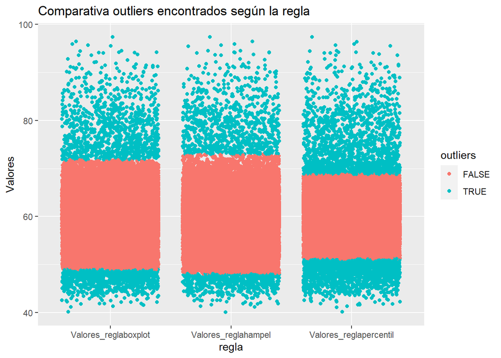

```r
df_tidyoutlier %>% pivot_longer(starts_with("Valores_regla"), "regla", values_to="outliers") %>% ggplot(aes(x=regla, y=Valores, color=outliers)) + geom_point(position="jitter") + labs(title="Comparativa outliers encontrados según la regla")
```

Los zona roja marca los valores que se encuentran en el rango normal según el método. Los demás puntos azules son los outliers que se detectan. Como se puede ver, estas dos reglas escogidas devuelven una cantidad de outliers parecida.

##5- ANÁLISIS UNIVARIANTE Y ESTADÍSTICOS BÁSICOS

Lo primero que haremos será reemplazar valores que no tengan sentido para el análisis (valores infinitos o negativos) de la variable de los valores de sonido, ya que tras visualizar el data frame podemos observar que existen valores infinitos, que pueden alterar los resultados.

```r
#View(df_tidy)
df_tidy <- df_tidy %>% mutate(Valores = ifelse(!is.finite(Valores)|Valores<0, NA, Valores))
```

Hacemos una breve comprobación de cuántas observaciones hay del total incompletas(con valores perdidos).

```r
sum(!complete.cases(df_tidy))
```

```
## [1] 2
```

Lo primero que haremos será extraer datos básicos a partir de la variable de los valores de sonido (rango intercuantil, media, mediana, desviación estándar y la MADM). Esta última necesitará de una función previa para calcularla. Hay que tener en cuenta que el df contiene NA, por lo que habrá que ignorarlos.

```r
df_tidyNO <- na.omit(df_tidy)

df_tidy %>% summarise_if(is.numeric, funs(IQR, mean, median, sd, madm), na.rm=T)
```

```
## # A tibble: 1 x 5
##     IQR  mean median    sd  madm
##   <dbl> <dbl>  <dbl> <dbl> <dbl>
## 1   5.7  60.4   60.5  5.69  4.15
```

```r
max <- max(df_tidyNO$Valores)
min <- min(df_tidyNO$Valores)
```

A parte de estos valores, podemos saber que el valor máximo de dB captado por los sensores es de 97.4.

Por otra parte, el valor mínimo total almacenado se quedará en 40.1 dB.

Una vez sabido esto, realizaremos un diagrama de dispersión para así visualizar que estos estadísticos básicos están bastante limitados en ciertos casos.

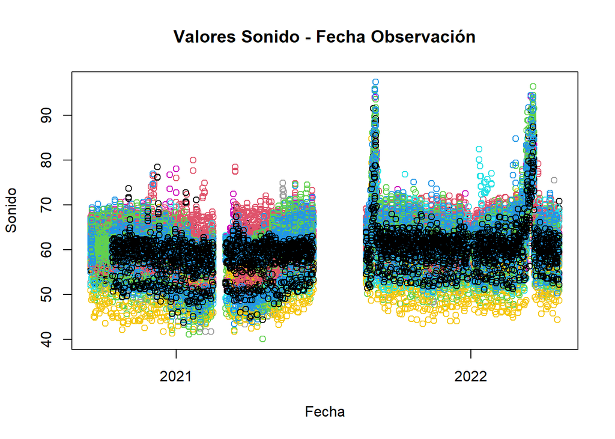

```r
plot(x = df_tidy$FechaObservacion, y = df_tidy$Valores, col = factor(df_tidy$IdEntidad), main = "Valores Sonido - Fecha Observación", xlab = "Fecha", ylab = "Sonido")
```

Los estadísticos pueden ser similares en distintos data frames aunque estos no se parezcan mucho, por lo que no pueden ser siempre la base para sacar los datos pertinentes.

Ahora realizaremos una comprobación para ver si los datos que tenemos siguen una distribución gaussiana. Para ello, utilizaremos la función qqplot, aunque también se podría hacer mediante gráficos de densidad, histogramas, etc. Para esta función en específico necesitaremos la galería car, añadida previamente en la instalación de paquetes.

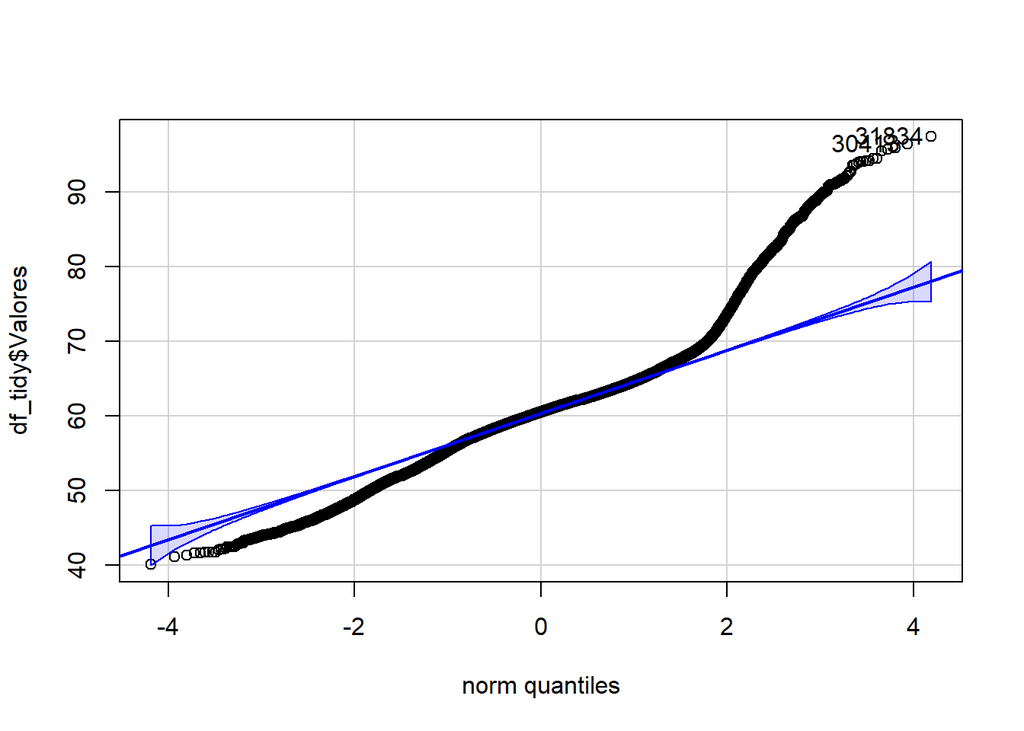

```
## [1] 31834 30413
```

```r
library(car)
qqPlot(df_tidy$Valores)
```

Realizaremos una visualización de los datos mediante un histograma, para que se puedan ver como se organizan los distintos valores de sonido. Además, añadiré una línea vertical que marcará la media de los valores y otra línea que marcará la densidad.

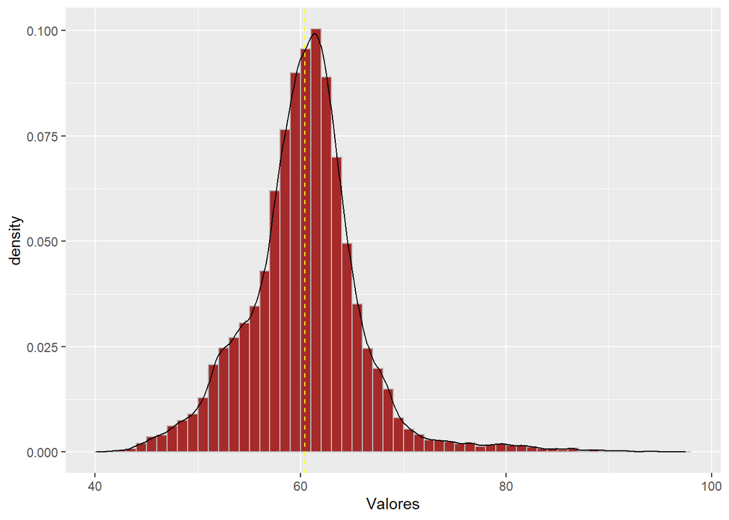

```r
df_tidy %>%  ggplot(aes(x=Valores)) + geom_histogram(aes(y=stat(density)), breaks=seq(40,98), col="grey", fill = "brown") + geom_density() + geom_vline(xintercept=mean(df_tidy$Valores, na.rm=T), col="yellow", linetype="dashed")
```

##6- ANÁLISIS BIVARIANTE (RELACIONES ENTRE VARIABLES)

Para poder comprobar la relación entre los periodos del día, necesitamos que cada uno de estos sea una variable diferente.

```r
df_tidy_wide <- df_tidy %>% distinct() %>% pivot_wider(names_from = "Periodo", values_from = "Valores") %>% select(-IdEntidad, -FechaObservacion)
colnames(df_tidy_wide) <- c("Medio", "Dia", "DiaTardeNoche", "Tarde", "Noche")
df_tidy_wideNO <- na.omit(df_tidy_wide)
```

Una vez tenemos el data frame preparado, nos disponemos a iniciar el análisis bivariante. Como disponemos de variables cuantitativas, (el nombre de la calle es discreta pero la relación discreta/continua no se ha dado aún) se utilizará para conocer su relación la covarianza y la correlación.

Empezaremos por midiendo la relación lineal entre variables mediante la covarianza de Pearson. Obtendremos la matriz de covarianza.

```r
cov(df_tidy_wideNO, method = 'pearson')
```

```
##                  Medio      Dia DiaTardeNoche    Tarde    Noche
## Medio         17.74173 15.91859      19.03054 17.96707 18.88526
## Dia           15.91859 15.68499      15.50674 15.07771 14.02427
## DiaTardeNoche 19.03054 15.50674      23.00433 21.14826 25.72680
## Tarde         17.96707 15.07771      21.14826 27.18157 23.21160
## Noche         18.88526 14.02427      25.72680 23.21160 32.93549
```

A continuación mediremos la misma relación pero esta vez usando la matriz de correlación.

```r
cor(df_tidy_wideNO, method = 'pearson')
```

```
##                   Medio       Dia DiaTardeNoche     Tarde     Noche
## Medio         1.0000000 0.9542552     0.9419944 0.8181671 0.7812551
## Dia           0.9542552 1.0000000     0.8163446 0.7302239 0.6170299
## DiaTardeNoche 0.9419944 0.8163446     1.0000000 0.8457316 0.9346497
## Tarde         0.8181671 0.7302239     0.8457316 1.0000000 0.7757749
## Noche         0.7812551 0.6170299     0.9346497 0.7757749 1.0000000
```

Finalmente, podemos obtener la matriz de correlación pero mediante el método de Spearman (el cual es robusto frente a outliers y útil para las relaciones no lineales).

```r
cor(df_tidy_wideNO, method="spearman")
```

```
##                   Medio       Dia DiaTardeNoche     Tarde     Noche
## Medio         1.0000000 0.9457990     0.8921936 0.7604888 0.6759840
## Dia           0.9457990 1.0000000     0.7336092 0.6501286 0.4849136
## DiaTardeNoche 0.8921936 0.7336092     1.0000000 0.8128995 0.9103940
## Tarde         0.7604888 0.6501286     0.8128995 1.0000000 0.7357997
## Noche         0.6759840 0.4849136     0.9103940 0.7357997 1.0000000
```

Como se ve los valores de esta matriz son muy similares a los del métodod de Pearson con una leve modificación en los valores.

Seguidamente, comprobaremos la relación entre dos variables en específico. Las que más nos interesan sería la de Día-Noche, Día-Tarde y Noche-Tarde.

```r
Rel_DN <- cor(df_tidy_wideNO$Dia, df_tidy_wideNO$Noche, method="pearson")

Rel_TN <- cor(df_tidy_wideNO$Tarde, df_tidy_wideNO$Noche, method="pearson")

Rel_DT <- cor(df_tidy_wideNO$Dia, df_tidy_wideNO$Tarde, method="pearson")
```

Observación: no haría falta escribir el parámetro method ya que, por defecto, se aplica el método de Pearson.

Los valores de la relación quedarán:

La relación entre los valores del día y de la noche es de 0.6170299.

La relación entre los valores de la tarde y de la noche es de 0.7757749.

La relación entre los valores del día y de la tarde es de 0.7302239.

La representación gráfica quedaría:

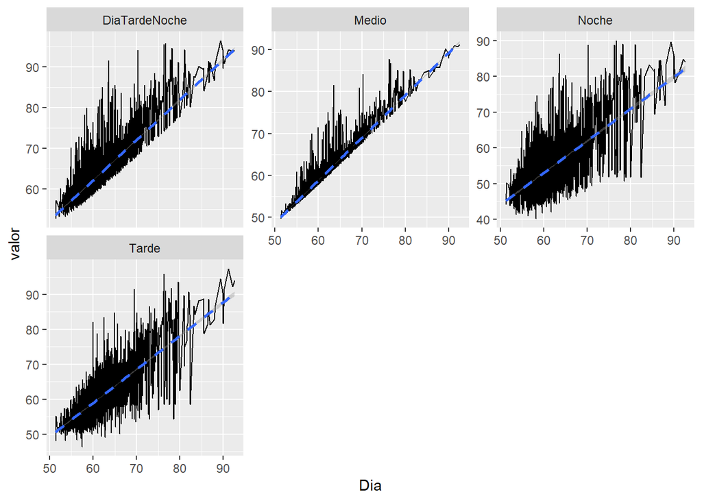

```r
ggplot(data=gather(df_tidy_wideNO,key=Y,value=valor, -Dia),aes(x=Dia,y=valor))+ geom_line() + facet_wrap(~Y,ncol=3, scales = 'free_y')+geom_smooth(method = "lm", linetype ="dashed")
```

La línea azul representa el ajuste lineal de datos.

También podemos representar dicha relación con la función ggpairs cuya librería ha sido cargada previamente. Esta herramienta permite visualizar perfectamente la correlación existente entre las variable de forma clara.

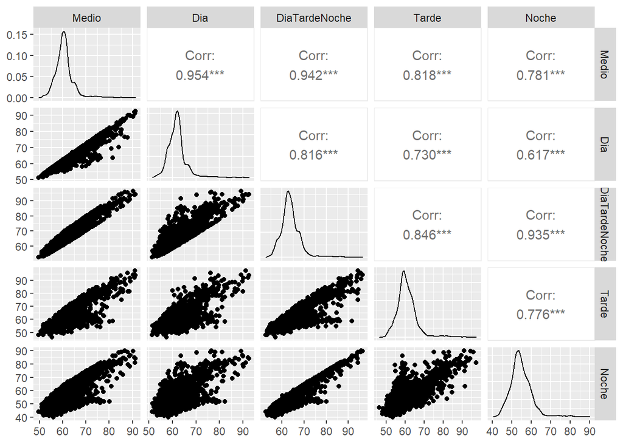

```r
ggpairs(df_tidy_wideNO)
```

Finalmente, mediante un diagrama de violín podemos representar la relación de ruido en función de la calle:

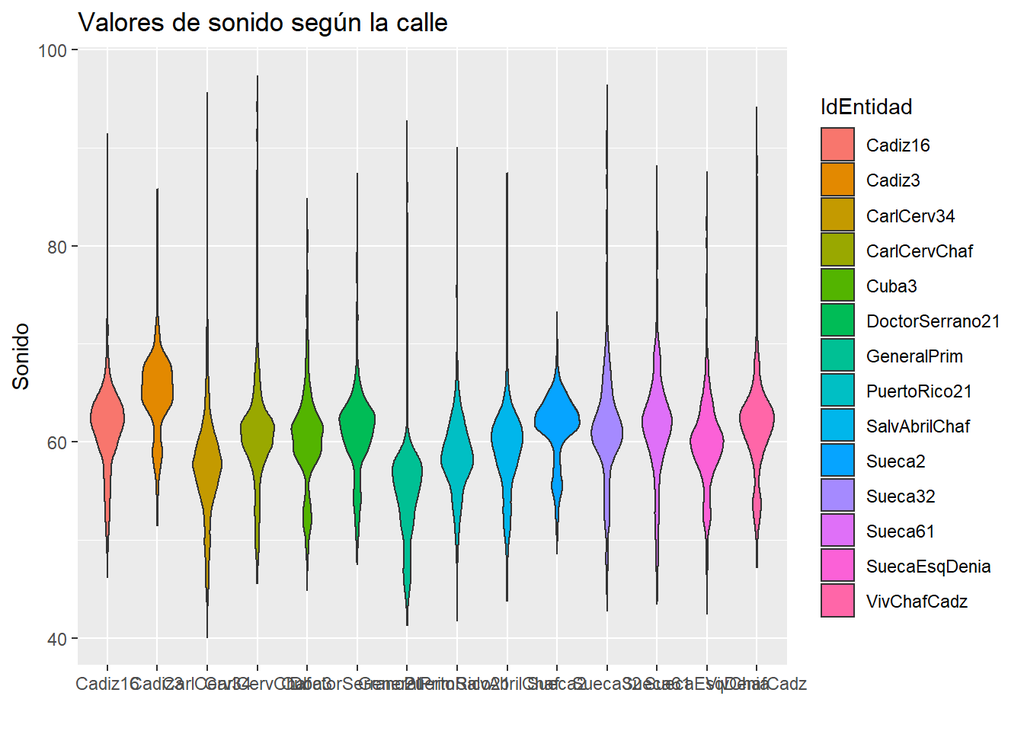

```r
ggplot(df_tidyNO, aes(IdEntidad, Valores, fill = IdEntidad)) +
  geom_violin() + labs(title="Valores de sonido según la calle", x=" ", y= "Sonido")
```

A continuación hemos planteado 7 preguntas las cuales más adelante responderemos.

## 7- PREGUNTAS PROPUESTAS

1. ¿Que calle es la mas ruidosa? ¿Y la que menos?
2. ¿Que mes del año tiene el maximo indice de ruido? ¿Y el minimo?
3. Relación o Media entre los indices de ruido maximos y minimos**
4. Existe alguna relación entre la evolución del ruido entre las distintas calles? Realiza una comparativa visual de forma interactiva
5. ¿Coinciden los meses con mas y menos sonido en cada año?
6. ¿Como afectaron las fallas?
7. ¿Como varía el ruido dependiendo de si es lunes o sábado?

LAeq_d <- 7-19h LAeq_den <- indice entre los tres dia, tarde, noche LAeq_e <- 19-23h LAeq_n <- 23-7h LAeq <- periodo estable de 1 min

### PREGUNTA 1: ¿Cual es la calle más ruidosa?¿Y la que menos?

Para realizar esta pregunta emplearemos la variable IdEntidad, la cual identifica la calle correspondiente; y la variable Valores, que determina el nivel de ruido que tiene dicha calle.

En primer lugar, calcularemos cual es la calle con mayor índice de ruido

```r
df_tidy%>%
  filter (Valores == max(Valores, na.rm = TRUE )) %>%
  dplyr::select(c(IdEntidad, Valores))
```

```
## # A tibble: 1 x 2
##   IdEntidad    Valores
##   <chr>          <dbl>
## 1 CarlCervChaf    97.4
```

La calle más ruidosa, con un índice de 97.4 es Carles Cervera, Chaflán Reina Doña María

En segundo lugar, calculamos la calle con menos índice de ruido

```r
df_tidy%>%
  filter (Valores == min(Valores, na.rm = TRUE )) %>%
  select(c(IdEntidad, Valores))
```

```
## # A tibble: 1 x 2
##   IdEntidad  Valores
##   <chr>        <dbl>
## 1 CarlCerv34    40.1
```

La calle menos ruidosa es Carles Cervera 34, con un índice de de 40.1; que si lo comparamos con la anterior, su valor baja a menos de la mitad.

Lo vamos a representar con un gráfico geom_point para que se visualice mejor.

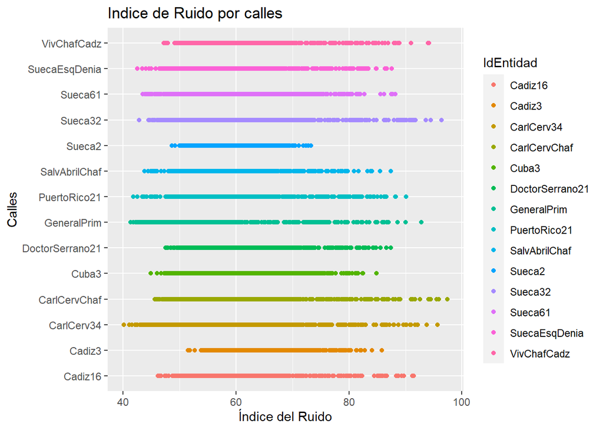

```r
ggplot(df_tidy,aes(x = IdEntidad, y=Valores, color = IdEntidad)) + geom_point() + labs(x = "Calles", y = "Índice del Ruido", title = "Indice de Ruido por calles") + coord_flip()
```

### PREGUNTA 2: ¿Que mes del año tiene el máximo indice de ruido? ¿Y el mínimo?**

Para contestar a la pregunta planteada, analizaremos las variables FechaObservacion, que contiene la fecha de la observacion como bien indica su nombre, y la variable Valores que contiene los indices de ruido de cada observacion. Para tener una mejor representacion de cada mes, agruparemos la variable FechaObservacion por el mes, y haremos la media de los Valores (indices de ruido) que le corresponden.

```r
library(lubridate)

df_meses <- df_tidy
df_meses$Month<-months(df_meses$FechaObservacion)
df_meses$Year<-format(df_meses$FechaObservacion,format="%y")


is.na(df_meses) <- sapply(df_meses, is.infinite)

media_meses <- df_meses %>% filter(!is.na(Valores)) %>% group_by(Month) %>% summarise(media_ruido = mean(Valores))
head(media_meses)
```

```
## # A tibble: 6 x 2
##   Month     media_ruido
##   <chr>           <dbl>
## 1 abril            59.2
## 2 agosto           61.1
## 3 diciembre        59.8
## 4 enero            58.7
## 5 febrero          59.5
## 6 junio            61.0
```

```r
#aggregate(Valores~Month,df_meses,mean)
```

Ahora que tenemos todos los datos limpiados y filtrados, podemos proceder a sacar las graficas y determinar los meses con mayor y menor indice de ruido:

```r
library(scales)
```

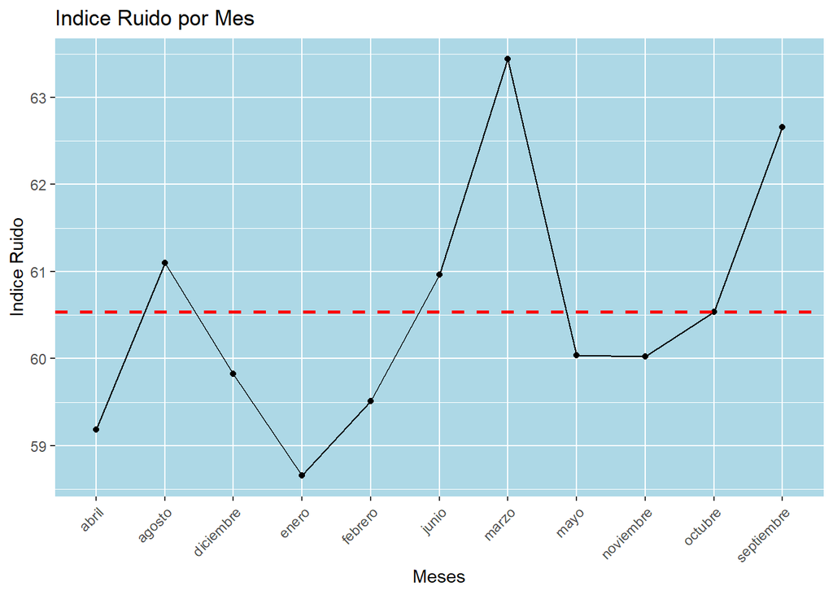

```r
media_meses %>% ggplot(aes(x = Month, y = media_ruido, group = 1), colour = Month) + geom_line() + geom_point() + labs(x = "Meses", y = "Indice Ruido", title = "Indice Ruido por Mes") + theme(axis.text.x=element_text(angle=45, hjust=1), panel.background = element_rect(fill = "lightblue")) + geom_hline(yintercept = mean(media_meses$media_ruido), color="red", lty="dashed", size = 1)
```

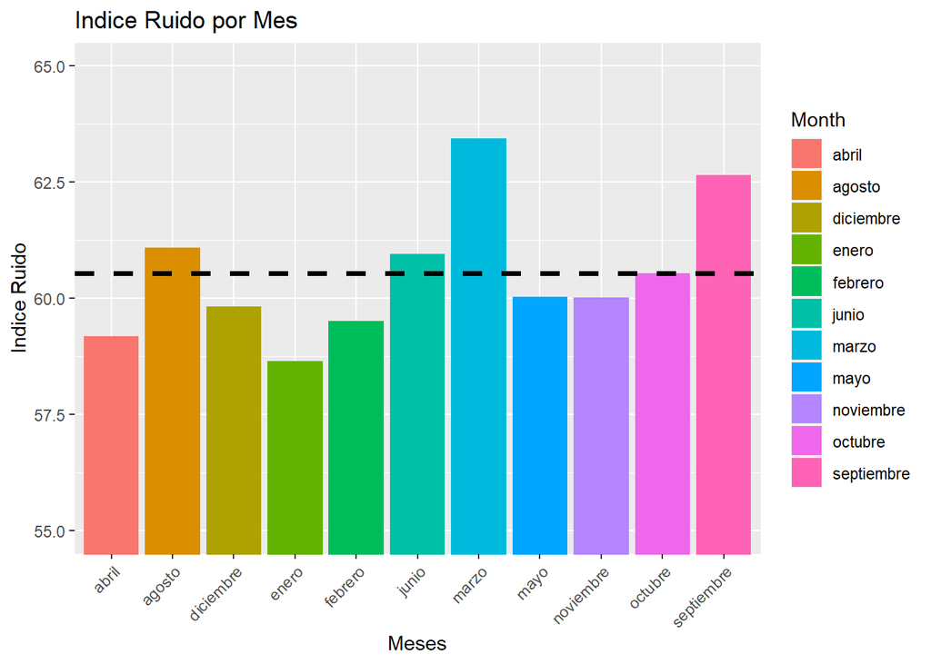

```r
media_meses %>% ggplot(aes(x = Month, y = media_ruido, fill = Month, ratio = 50)) + geom_bar(stat = "identity") + labs(x = "Meses", y = "Indice Ruido", title = "Indice Ruido por Mes") +  theme(axis.text.x=element_text(angle=45, hjust=1)) + scale_y_continuous(limits = c(55,65), oob = rescale_none) + geom_hline(yintercept = mean(media_meses$media_ruido), color="black", lty="dashed", size = 1.25)
```

```r
#Mayor indice de ruido:
maximo <- filter(media_meses, media_ruido == max(media_ruido))
maximo
```

```
## # A tibble: 1 x 2
##   Month media_ruido
##   <chr>       <dbl>
## 1 marzo        63.4
```

```r
#Menor indice de ruido:
minimo <- filter(media_meses, media_ruido == min(media_ruido))
minimo
```

```
## # A tibble: 1 x 2
##   Month media_ruido
##   <chr>       <dbl>
## 1 enero        58.7
```

```r
#Diferencia en numero real:
maximo$media_ruido - minimo$media_ruido
```

```
## [1] 4.783661
```

```r
#Diferencia en porcentaje:
((maximo$media_ruido / minimo$media_ruido)*100)-100
```

```
## [1] 8.15568
```

```r
#Media de indicee de ruido por mes:
mean(media_meses$media_ruido) #60.53897
```

```
## [1] 60.53897
```

Para concluir, podemos afirmar que el mayor indice de ruido lo tiene el mes de Marzo (63.43801). Una explicación lógica a esta conclusión podría ser que las Falls de Valencia se celebran ese mismo mes y por tanto el ruido sobrepasa la media. El mes de enero resulta tener el menor indice de ruido (58.65435), que seguramente sea debido a que segun los estudios meteorológicos es el mes más frío en España. Como dato adiccional, hemos calculado la diferencia entre los dos datos obtenidos, que es 4.783661 o bien un 8.15568%.

### PREGUNTA 3: Relación o Media entre los indices de ruido maximos y minimos**

```r
#Vamos a crear un data frame con todas las observaciones para
#los meses que hemos obtenido en el apartado anterior
#Enero y Marzo.

df_meses_rel <- df_meses %>% filter(Month == "enero" | Month == "marzo")

df_meses_rel$Day <- format(df_meses_rel$FechaObservacion,format="%d")
```

```r
#df_meses_rel %>% ggplot(aes(x = Valores, y = Day, colour = Month)) + geom_point()

#Media entre ambos valores:
(maximo$media_ruido + minimo$media_ruido)/2
```

```
## [1] 61.04618
```

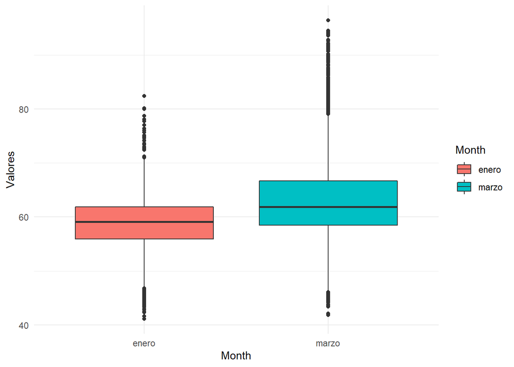

```r
#df_meses_rel$Valores <- as.factor(df_meses_rel$Valores)

df_meses_rel %>% ggplot(aes(x=Month, y = Valores, fill = Month)) + geom_boxplot() + theme_minimal()
```

### PREGUNTA 4. Existe alguna relación entre la evolución del ruido entre las distintas calles? Realiza una comparativa visual de forma interactiva

Filtramos, agrupamos, calculamos las medias de los valores en función de los grupos y juntamos con tal de obtener una nueva columna que contenga la información del año y del mes

```r
filtrado = df_tidy %>% filter(Periodo == 'LAeq') %>% group_by(año = year(FechaObservacion), mes =  month(FechaObservacion), calle = IdEntidad) %>% summarise(media_mes = mean(Valores)) %>% unite(año_mes, año:mes, sep = ' ')
```

Cambiamos los nombres de esta nueva columna creada, con tal de después (ya siendo valores enteros) poder representar ordenadamente los distintos meses en el eje X

```r
#Cambiamos los nombres
filtrado = filtrado %>%  mutate(año_mes = ifelse(año_mes == '2020 9', 1, año_mes))%>%
                mutate(año_mes = ifelse(año_mes == '2020 10', 2, año_mes))%>%
                mutate(año_mes = ifelse(año_mes == '2020 11', 3, año_mes))%>%
                mutate(año_mes = ifelse(año_mes == '2020 12', 4, año_mes))%>%
                mutate(año_mes = ifelse(año_mes == '2021 1', 5, año_mes))%>%
                mutate(año_mes = ifelse(año_mes == '2021 2', 6, año_mes))%>%
                mutate(año_mes = ifelse(año_mes == '2021 3', 7, año_mes))%>%
                mutate(año_mes = ifelse(año_mes == '2021 4', 8, año_mes))%>%
                mutate(año_mes = ifelse(año_mes == '2021 5', 9, año_mes))%>%
                mutate(año_mes = ifelse(año_mes == '2021 6', 10, año_mes))%>%
                mutate(año_mes = ifelse(año_mes == '2021 8', 11, año_mes))%>%
                mutate(año_mes = ifelse(año_mes == '2021 9', 12, año_mes))%>%
                mutate(año_mes = ifelse(año_mes == '2021 10', 13, año_mes))%>%
                mutate(año_mes = ifelse(año_mes == '2021 11', 14, año_mes))%>%
                mutate(año_mes = ifelse(año_mes == '2021 12', 15, año_mes))%>%
                mutate(año_mes = ifelse(año_mes == '2022 1', 16, año_mes))%>%
                mutate(año_mes = ifelse(año_mes == '2022 2', 17, año_mes))%>%
                mutate(año_mes = ifelse(año_mes == '2022 3', 18, año_mes))%>%
                mutate(año_mes = ifelse(año_mes == '2022 4', 19, año_mes))


#Convertimos a tipo entero
filtrado$año_mes <- as.integer(filtrado$año_mes)
```

Generamos un gráfico interactivo con el usuario, de forma que a medida que el usuario seleccione entre las distintas calles, podremos ver la media de sonido para cada mes para las opciones seleccionadas.

De este modo, podremos realizar de forma interactiva la comparativa entre las calles que se desee.

```r
library(shiny)
library(shinyWidgets)

#Definimos la función de interfaz de usuario
ui <- fluidPage(
  fluidRow(
    column(6, pickerInput("calle","Selecciona la calle que usted desee", choices = filtrado$calle, options = list(`actions-box` = TRUE),multiple = T))),
  fluidRow(
     plotOutput("grafico")
          )
)

#Definimos la función del servidor
server <- function(input, output){

  #Generamos el dataframe en función de las opciones seleccionadas por el usuario
  datos <-reactive(filtrado %>% filter(calle == input$calle[1] | calle == input$calle[2]  | calle == input$calle[3]|   calle == input$calle[4]| calle == input$calle[5] | calle == input$calle[6] | calle == input$calle[7] | calle ==     input$calle[8] | calle == input$calle[9] | calle == input$calle[10] | calle == input$calle[11] | calle == input$calle[12] | calle == input$calle[13]| calle == input$calle[14]))

  #Realizamos un gráfico en función de las opciones seleccionadas por el usuario
  output$grafico <-  renderPlot({
    ggplot(data = datos(), aes(x = año_mes, y = media_mes, colour = calle )) + geom_point(size = 3) + geom_line() +
    labs(x = 'Mes', y = 'Ruido (dBA)', title = 'Distribución del nivel sonoro') + scale_x_continuous(breaks = c(1:19))+      scale_y_continuous(limit = c(54,69))
  })

}

#Interconectamos ambas funciones
shinyApp(ui = ui, server = server)
```

[output not shown]

Shiny applications not supported in static R Markdown documents

### PREGUNTA 5. ¿Coinciden los meses con mas y menos sonido en cada año?

Primero de todo analizaremos el intervalo que tenemos en la fecha de observación, es decir buscaremos cual es la fecha más antigua, y cual es la mas reciente

```r
table(df_meses$Year)
```

```
##
##    20    21    22
##  7565 20240  7490
```

```r
#Podemos ver que solo estamos analizando los años 2020, 2021 y 2022

#Buscamos cual ha sido la fecha más antigua en la que se hizo una observacion:
min(df_meses$FechaObservacion) #desde el 17 de sepitiembre del 2020
```

```
## [1] "2020-09-17"
```

```r
#Fecha más raciente de la observación:
max(df_meses$FechaObservacion) #20 de abril 2022
```

```
## [1] "2022-04-20"
```

Tras haber realizado el análisis, podemos concluir que la fecha más reciente es 20 de abril 2022, y la fecha más antigua es 17 de septiembre 2020. Por tanto para contestar a la pregunta que nos habiamos planteado, ¿Coinciden los meses con mas y menos sonido en cada año?, deberemos tener en cuenta que las observaciones de los años 2020 y 2022 no son del año entero sino de casi la mitad, por tanto los datos obtenidos no seran realmente veríficos.

A continuación crearemos un data frame para las observaciones de cada año:

```r
#Creamos un data frame para cada año y sus observaciones.
a20_meses <- df_meses %>% filter(Year == "20" & !is.na(Valores))
count(a20_meses)
```

```
## # A tibble: 1 x 1
##       n
##   <int>
## 1  7565
```

```r
a21_meses <- df_meses %>% filter(Year == "21" & !is.na(Valores))
count(a21_meses)
```

```
## # A tibble: 1 x 1
##       n
##   <int>
## 1 20238
```

```r
a22_meses <- df_meses %>% filter(Year == "22" & !is.na(Valores))
count(a22_meses)
```

```
## # A tibble: 1 x 1
##       n
##   <int>
## 1  7490
```

Podemos darnos cuenta de que el año 2020 tiene 7565 observaciones, el año 2021 tiene 20238 y el año 2022 tiene 7490. Asi que está claro que el año con nos dará el resultado más preciso es el año 2021.

A continuación buscaremos el mes con más y menos ruido para cada año y los representaremos para ver mejor las diferencias y sus evoluciones:

Año 2020:

```r
a20_meses_rel <- a20_meses %>% filter(!is.na(Valores)) %>% group_by(Month) %>% summarise(media_ruido = mean(Valores))
head(a20_meses_rel)
```

```
## # A tibble: 4 x 2
##   Month      media_ruido
##   <chr>            <dbl>
## 1 diciembre         59.3
## 2 noviembre         59.7
## 3 octubre           59.7
## 4 septiembre        59.8
```

```r
a20_meses_rel %>% filter(media_ruido == max(media_ruido))
```

```
## # A tibble: 1 x 2
##   Month      media_ruido
##   <chr>            <dbl>
## 1 septiembre        59.8
```

```r
a20_meses_rel %>% filter(media_ruido == min(media_ruido))
```

```
## # A tibble: 1 x 2
##   Month     media_ruido
##   <chr>           <dbl>
## 1 diciembre        59.3
```

El mes con más ruido (**59.76343**) del año **2020** es **Septiembre**, y el mes con menos media de ruido (**59.25526**) es **Diciembre**.

Año 2021:

```r
a21_meses_rel <- a21_meses %>% filter(!is.na(Valores)) %>% group_by(Month) %>% summarise(media_ruido = mean(Valores))
head(a21_meses_rel)
```

```
## # A tibble: 6 x 2
##   Month     media_ruido
##   <chr>           <dbl>
## 1 abril            58.4
## 2 agosto           61.1
## 3 diciembre        60.4
## 4 enero            57.5
## 5 febrero          57.2
## 6 junio            61.0
```

```r
a21_meses_rel %>% filter(media_ruido == max(media_ruido))
```

```
## # A tibble: 1 x 2
##   Month      media_ruido
##   <chr>            <dbl>
## 1 septiembre        63.8
```

```r
a21_meses_rel %>% filter(media_ruido == min(media_ruido))
```

```
## # A tibble: 1 x 2
##   Month   media_ruido
##   <chr>         <dbl>
## 1 febrero        57.2
```

El mes co más ruido del año **2021** es **Septiembre**, con **63.82947** de indice, y **Febrero** es el que menor indice de ruido tiene **57.193.**

Año 2022:

```r
a22_meses_rel <- a22_meses %>% filter(!is.na(Valores)) %>% group_by(Month) %>% summarise(media_ruido = mean(Valores))
head(a22_meses_rel)
```

```
## # A tibble: 4 x 2
##   Month   media_ruido
##   <chr>         <dbl>
## 1 abril          60.4
## 2 enero          60.0
## 3 febrero        60.9
## 4 marzo          66.7
```

```r
a22_meses_rel %>% filter(media_ruido == max(media_ruido))
```

```
## # A tibble: 1 x 2
##   Month media_ruido
##   <chr>       <dbl>
## 1 marzo        66.7
```

```r
a22_meses_rel %>% filter(media_ruido == min(media_ruido))
```

```
## # A tibble: 1 x 2
##   Month media_ruido
##   <chr>       <dbl>
## 1 enero        60.0
```

En el año 2022, el mes con mayor indice de ruido es Marzo con 66.65673 y el menor es Enero con 59.98954.

Finalmente podemos concluir que los meses con menor ruido han ido cambiando, pero los tres meses pertenecen a invierno asi que podemos decir que sigue la idea principal, de que los meses más silenciosos son en invierno.

En cambio, el mes con más ruido en los años 2020 y 2021 es Septiembre y del año 2022 es en Marzo. Lo más seguro que este cambio tan brusco sea debido a que este año se han celerado las fallas y en los dos años anteriores no por la pandemia.

### PREGUNTA 6. ¿Cómo afectaron las fallas?

Generamos un dataframe que contendrá las medias de sonido de cada día para el mes de marzo de 2021

```r
library(lubridate)

df_fallas_2021 = df_tidy %>% filter(FechaObservacion >= '2021-03-01' & FechaObservacion <= '2021-03-31') %>% group_by(FechaObservacion) %>% summarise(media_dia = mean(Valores, na.rm = TRUE), FechaObservacion = day(FechaObservacion)) %>% distinct()
```

Generamos un dataframe que contendrá las medias de sonido de cada día para el mes de marzo de 2022

```r
df_fallas_2022 = df_tidy %>% filter(FechaObservacion >= '2022-03-01' & FechaObservacion <= '2022-03-31') %>% group_by(FechaObservacion) %>% summarise(media_dia = mean(Valores, na.rm = TRUE), FechaObservacion = day(FechaObservacion)) %>% distinct()
```

Obtenemos un nuevo dataframe, calculamos columna de las medias y reprensentamos

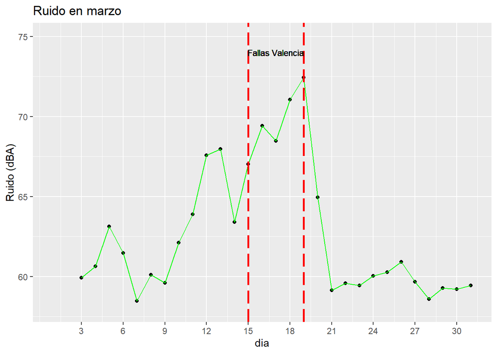

```r
#Unimos ambos dataframes
df_fallas = full_join(df_fallas_2021, df_fallas_2022, by = "FechaObservacion")

#Calculamos una columna que contendrá las medias de ruidos entre ambos dataframes
df_fallas = df_fallas %>% mutate(media_dia = abs(media_dia.x + media_dia.y)/2)

#Representamos las medias de ruidos para el mes de marzo
ggplot(data = df_fallas, aes(x = FechaObservacion, y = media_dia)) + geom_point() + geom_line(colour = 'green') + labs(title = 'Ruido en marzo', x = 'dia', y = 'Ruido (dBA)') + geom_vline(xintercept = day('2021-03-15'), size = 1, colour = 'red', linetype = 'longdash' ) + geom_vline(xintercept = day('2021-03-19'), size = 1, colour = 'red', linetype = 'longdash' )  +  scale_x_continuous(breaks = seq(3,31,3)) + scale_y_continuous(limit = c(58,75)) + geom_text( x = 17, y = 74, label = "Fallas Valencia", size = 3)
```

### PREGUNTA 7: ¿Cómo varía el ruido dependiendo de si es lunes o sábado?

```r
lunes <- df_tidy %>% filter(wday(FechaObservacion)=='2')
sabado <- df_tidy %>% filter(wday(FechaObservacion)=='7')
```

A continuación, cambiaremos el formato de la fecha para que más tarde represntarlo sea más fácil.

```r
for (x in lunes){
  lunes$FechaObservacion = 'Lunes'
}
for (x in sabado){
  sabado$FechaObservacion = 'Sábado'
}
```

Juntamos los dos dataframes:

```r
junto <- rbind(lunes, sabado)
```

Por último, representamos el dataframe y vemos las diferencias.

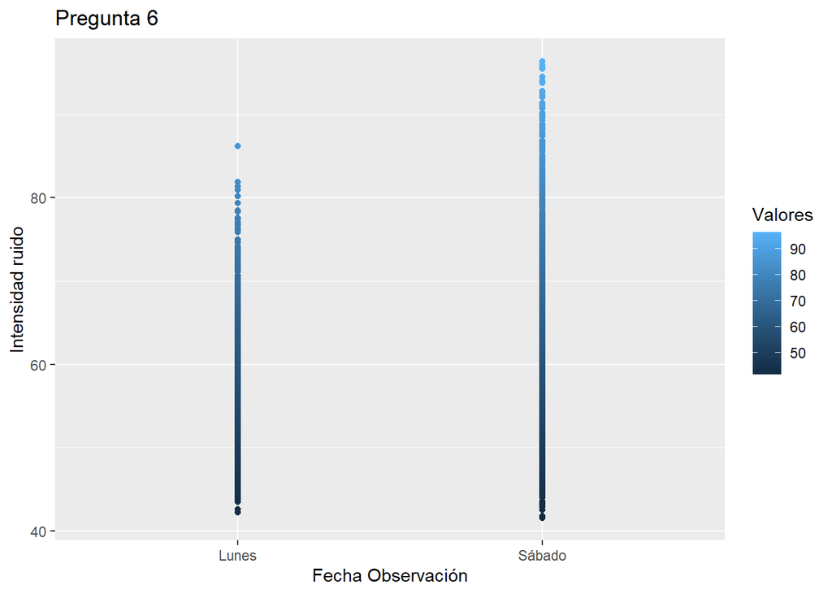

```r
junto %>% ggplot(aes(x=FechaObservacion, y = Valores, color= Valores)) + geom_point() + labs(title = 'Pregunta 6', x = 'Fecha Observación', y = 'Intensidad ruido')
```